# From the command line: rmarkdown::render(‘FLAIRR.Rmd’, params=list(data=“../processed_samples/1001-667/results/reports”, sample=“1001-667”))

# Read Lengths

pRESTO’s FilterSeq tool is used here to remove reads which are shorter than the nominated length.

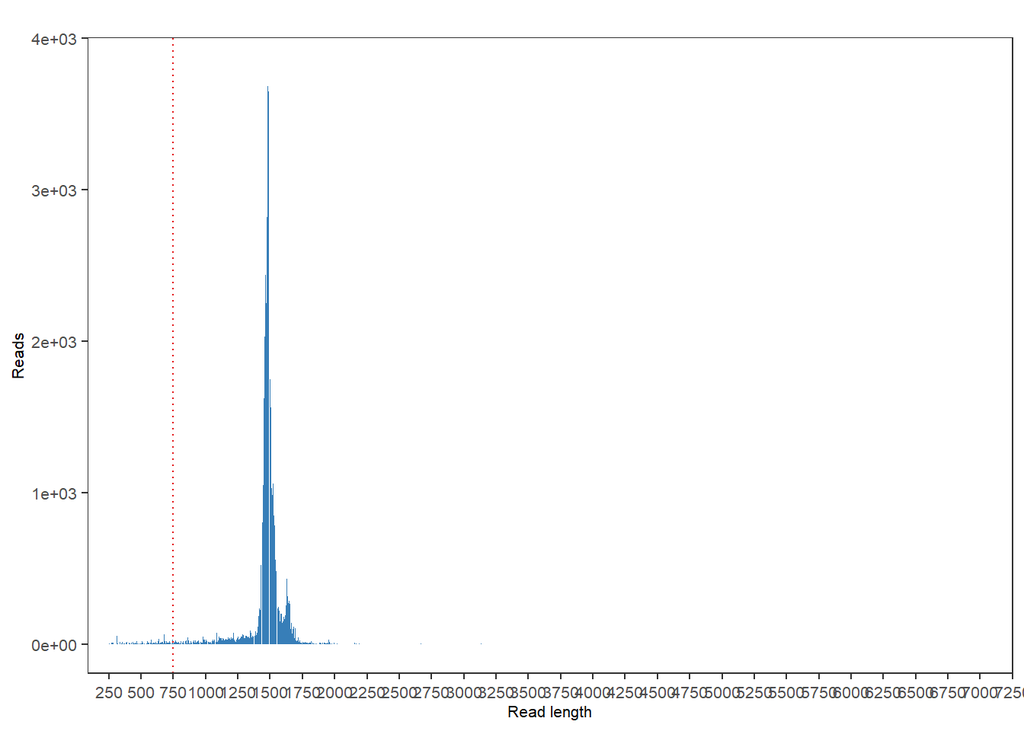

Figure 2: Read length distribution. The dotted line indicates the length of750 under which reads were removed. Reads shorter than this are unlikely to cover the full V and C region.

# Primer Identification

The MaskPrimers tool supports identification of multiplexed primers and UMIs. Identified primer regions may be masked (with Ns) or cut to mitigate downstream SHM analysis artifacts due to errors in the primer region. An annotion is added to each sequences that indicates the UMI and best matching primer. In the case of the constant region primer, the primer annotation may also be used for isotype assignment.

## Count of primer matches

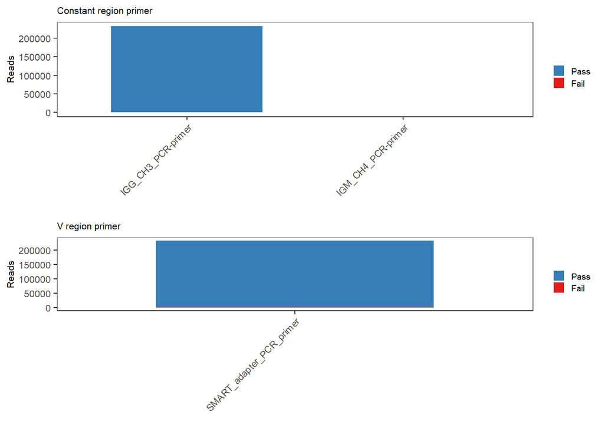

Figure 3: Count of assigned primers. The bar height indicates the total reads assigned to the given primer, stacked for those under the error rate threshold (Pass) and over the threshold (Fail).